# Vandana_Vamsi Krishna Notebook

# Start time 10:00pm

library(ggplot2) library(corrplot) library(rpart) library(randomForest) library(e1071) library(corrplot) library(tree) library(nnet) library(e1071)

# Reading the Datasets

Train_Data = read.csv(‘/Users/vamsi_5/Desktop/data-challenge/training_data.csv’, header = TRUE) Test_Data = read.csv(‘/Users/vamsi_5/Desktop/data-challenge/test_data.csv’, header = TRUE)

# From the frequency table, weight has 78844 unknown values, it doesnt help in prediction

ftable(Train_Data$weight)

# Summary of all the features

summary(Train_Data)

# Removing columns which are unwanted to the prediction

Train_Data<- subset(Train_Data,select=-c( encounter_id,patient_nbr, weight,payer_code, medical_specialty,examide,citoglipton,metformin.rosiglitazone)) Test_Data<- subset(Test_Data,select=-c( patient_nbr, weight,payer_code, medical_specialty,examide,citoglipton,metformin.rosiglitazone))

# Removing the observations, which has “?” in one of the columns from 1 to 42.

for (i in 1: 42){ Train_Data=Train_Data[Train_Data[i] != “?”,] Test_Data= Test_Data[Test_Data[i] != “?”,] }

# Now the observations are 78466 of 42 variables

Test_Data_1 <- Test_Data[-1]

# Convert into factors/levels

Train_Data_2 <- cbind(Train_Data[c(7:13,17)], lapply(Train_Data[c(1:6,14:16,18:42)],factor)) Test_Data_2 <- cbind(Test_Data_1[c(7:13,17)], lapply(Test_Data_1[c(1:6,14:16,18:41)],factor)) head(Train_Data_2)

# Data Visualization for insights, Plots and Distributions

# Data in Age column is skewed towards the right

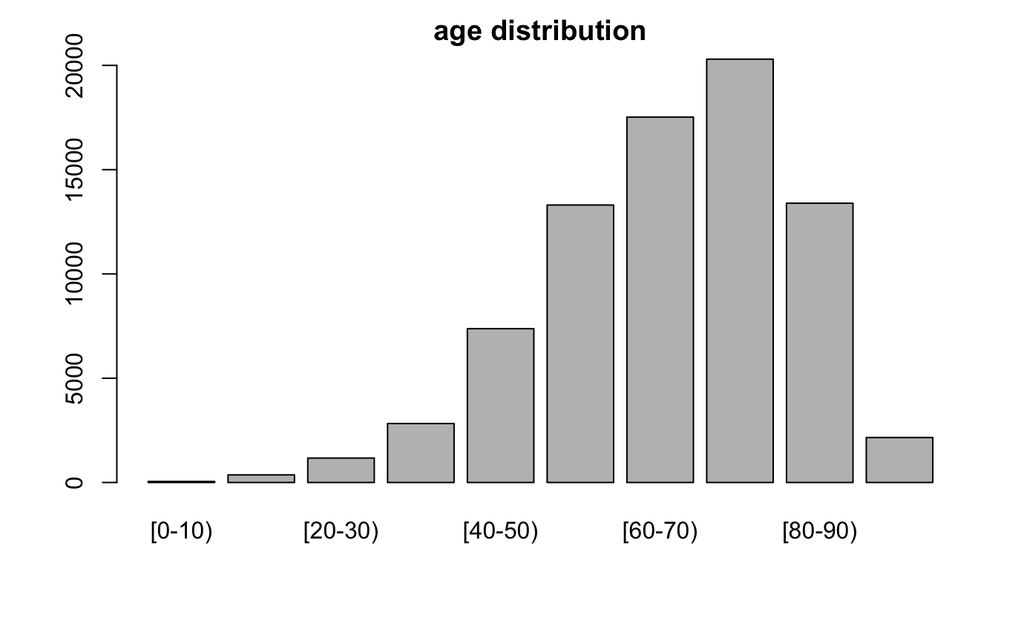

```r
plot(Train_Data_2$age, main = "age distribution")
```

# Females are higher than the males

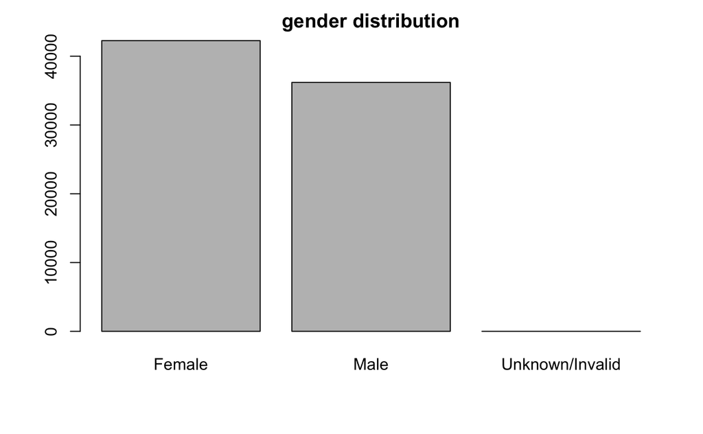

```r
plot(Train_Data_2$gender, main = "gender distribution")
```

# Caucassians are very high in compared to other races, they are followed by Africian_Americans.

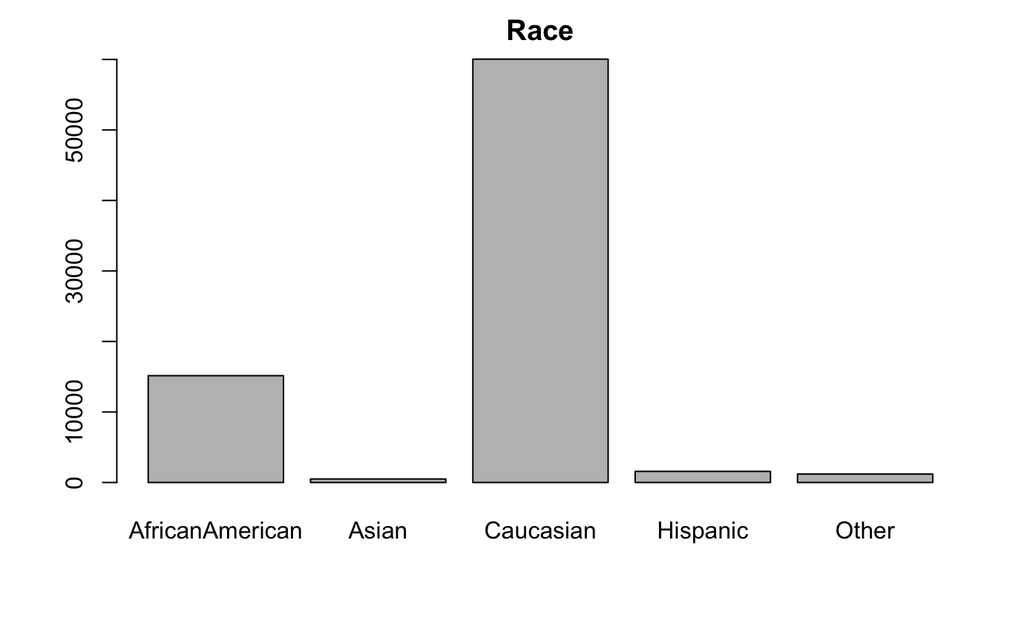

```r
plot(Train_Data_2$race, main = "Race")
```

# Plot between time_in_hospital vs age

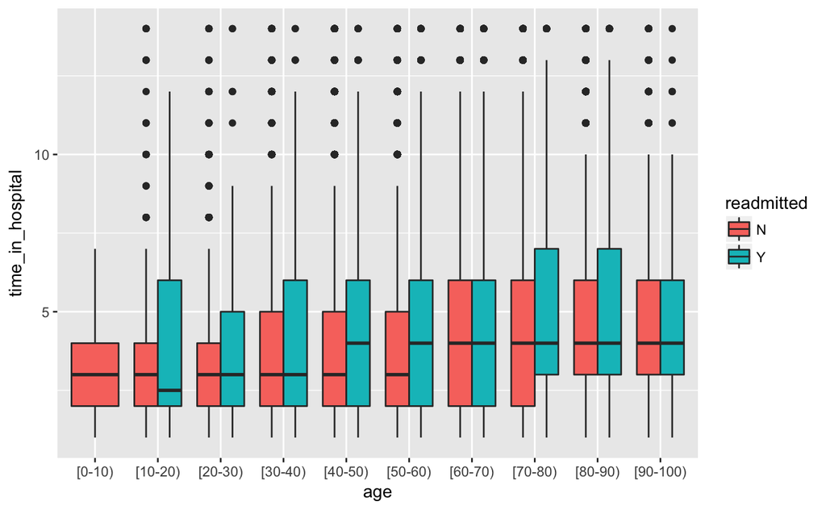

```r
g <- ggplot(Train_Data_2, aes(x=age, y=time_in_hospital))
g + geom_boxplot(aes(fill=readmitted))
```

# Readmission Comparison with gender

```r
Gender_Table <- table(Train_Data_2$readmitted,Train_Data_2$gender)
Gender_Table
```

```
    Female  Male Unknown/Invalid
  N  37506 32111               1
  Y   4763  4085               0
```

# Readmission Comparison with Age(Age’s between 70 - 80 are the majority who gets readmitted)

```r
Age_Table<- table(Train_Data_2$readmitted,Train_Data_2$age)
Age_Table
```

```
    [0-10) [10-20) [20-30) [30-40) [40-50) [50-60) [60-70) [70-80) [80-90) [90-100)
  N     51     343    1007    2510    6565   11996   15544   17891   11793     1918
  Y      0      22     165     318     810    1309    1978    2408    1599      239
```

# Diag_1, Diag_2 Diag_3 parameters has lot of levels reducing it.

Train_Data_2$diag_1<- as.character(Train_Data_2$diag_1) Train_Data_2$diag_2<- as.character(Train_Data_2$diag_2) Train_Data_2$diag_3<- as.character(Train_Data_2$diag_3)

Test_Data_2$diag_1<- as.character(Test_Data_2$diag_1) Test_Data_2$diag_2<- as.character(Test_Data_2$diag_2) Test_Data_2$diag_3<- as.character(Test_Data_2$diag_3)

# Function to reduce the levels of diag_1, diag_2 and diag_3(There are lot of factors which need to be reduced)

func <- function(x) { if (startsWith(x, “E”)) { value = 1 } else if (startsWith(x, “V”)) { value = 2 } else { x = as.numeric(x)

```
if (x < 140) {
  value = 1
}
else if (x >= 140 && x < 350) {
  value = 2
}
else if (x >= 350 && x < 550) {
  value = 3
}
else {
  value = 4
}
```

} }

# Applying the function and applying as.factor

Train_Data_2$diag_1 <- lapply(Train_Data_2$diag_1,func)  
Train_Data_2$diag_1 <- as.factor(unlist(Train_Data_2$diag_1))

Train_Data_2$diag_2 <- lapply(Train_Data_2$diag_2,func)  
Train_Data_2$diag_2 <- as.factor(unlist(Train_Data_2$diag_2))

Train_Data_2$diag_3 <- lapply(Train_Data_2$diag_3,func)  
Train_Data_2$diag_3 <- as.factor(unlist(Train_Data_2$diag_3))

Test_Data_2$diag_1 <- lapply(Test_Data_2$diag_1,func)  
Test_Data_2$diag_1 <- as.factor(unlist(Test_Data_2$diag_1))

Test_Data_2$diag_2 <- lapply(Test_Data_2$diag_2,func)  
Test_Data_2$diag_2 <- as.factor(unlist(Test_Data_2$diag_2))

Test_Data_2$diag_3 <- lapply(Test_Data_2$diag_3,func)  
Test_Data_2$diag_3 <- as.factor(unlist(Test_Data_2$diag_3))

# Logisitc Regression : Linear model - It gives out probabilities to classify the binomial classes.

# Using all the columns for the prediction

fit_all <- glm(readmitted ~.- number_inpatient, data=Train_Data_2, family=binomial) summary(fit_all)

# Using the test data and predicting with the help of glm model

```r
pred <-predict(fit_all, newdata=Test_Data_2 ,type = "response")
final_pred <-ifelse((pred<0.3),"No","Yes")
table(final_pred)
```

```
final_pred
   No   Yes
19393   193
```

# Tree based model, Random Forest is much more complex model than a linear model.

```r
Rf_fit<-randomForest(formula=readmitted ~ age+admission_type_id+num_lab_procedures+num_procedures+num_medications
                     +number_outpatient+ number_emergency+number_inpatient+number_diagnoses+
                       insulin+change+diabetesMed+diag_1+diag_2+diag_3,
                     data=Train_Data_2)
pred1 <-predict(Rf_fit , newdata= Test_Data_2,type = "response")
table(pred1)
```

```
pred1
    N     Y
19553    33
```

# Neural Networks, It is more complex than the above two models, NNet predicted almost all the test data into single class.

# Complex models won’t always give accurate results.

```r
nnet_model <- nnet(formula = readmitted ~ age+admission_type_id+num_lab_procedures+num_procedures+num_medications
                   +number_outpatient+ number_emergency+number_inpatient+number_diagnoses+
                     insulin+change+diabetesMed+diag_1+diag_2+diag_3,
                   data=Train_Data_2,size = 10, maxit = 100)
pred2 <-predict(nnet_model, newdata= Test_Data_2,type = "class")
table(pred2)
```

```
pred2
    N     Y
19571    15
```

Test_Data$Readmittance <- final_pred write.csv(Test_Data, “Vandana_Vamsi Krishna.csv”)

# Endtime 12am